# Práctica Final Data Driven Security

Grup CC: Toni Jordan Y Joan Dalmau

Junio de 2023

# 1 Objetivo

El objetivo de esta práctica es realizar un estudio de un subconjunto del Dataset de incidentes KDD CUP 99 para determinar cual es el mejor conjunto de variables que podamaos usar en un entrenamiento de Machine Learnings y Finalmente conseguir un juego de Dataset y modelo de entreno que mejore el valor obtenido por el script del enunciado.

Para poder llevar a cabo este estudio se dispone de dos datasets e información sobre los estandar Mitre de ATT&CK y las conclusiones sobre los incidentes.

## 1.1 Packages

Para la realización de este proyecto se usan los siguientes packages de R: (revisar da error al generar)

Required:

| randomForest |
| --- |
| nnet |
| readr |
| caret |

| e1071 |
| --- |
| dplyr |
| ggplot2 |
| doParallel |

| data.table |
| --- |
| kableExtra |
| corplot |
| class |
| knitr |
| tidyr |

# 2 Análisis y preprocesamiento de los conjuntos de datos

En esta sección, realizaremos un análisis exploratorio de los conjuntos de datos “Dataset Global” y “Dataset Muestra”. También llevaremos a cabo un preprocesamiento de los datos para asegurarnos de que sean adecuados para su uso en el entrenamiento de modelos de aprendizaje automático.

## 2.1 Carga de los conjuntos de datos

Comenzamos cargando los conjuntos de datos “Dataset Global” y “Dataset Muestra” en R.

## 2.2 1.- Validación y pre-porcesado del Dataset Muestra respecto al Dataset Global entregado

1.1.- Estudio del Dataset Muestra y su contenido 1.2.- Se valida que el Dataset Muestra no contiene duplicados 1.3.- Se valida que el Dataset Muestra tiene las muestra suficientes de la variable “Attack” para mantener las mismas proporciones que el Dataset Global. 1.4.- Se valida si es posible augmentar el número de muestras con el Dataset Global 1.5.- Se decide que hacer con las variables con muy bajas muestras

## 2.3 2.- Selector de variables

2.1.- Criterios de la selección y competividad de los precurosores con RandomFores 2.2.- Comparativa de diferentes modelos ML 2.3.- Optimización del ML y conclusiones

## 2.4 3.- Mejora de la información y valor añadido

3.1.- estudios EDA de las variables 3.2.- información agregada MITRE ATT&CK y CWE ## Exploración de los conjuntos de datos

A continuación, realizaremos un análisis exploratorio de los conjuntos de datos para comprender su estructura y contenido.

```r
# Visualizar las primeras filas del Dataset Global
head(data_full)
```

| Duration | ProtocolType | Service | Flag | SrcBytes | DstBytes | Land | WrongFragment | Urgent | Hot | NumFailedLogin | LoggedIn | NumCompromised | RootShell | SuAttempted | NumRoot | NumFile | NumShells | NumAccessFiles | NumOutboundCmds | IsHostLogin | IsGuestLogin | Count | SrvCount | SerrorRate | SrvSerrorRate | RerrorRate | SrvRerrorRate | SameSrvRate | DiffSrvRate | … |
| --- | --- | --- | --- | --- | --- | --- | --- | --- | --- | --- | --- | --- | --- | --- | --- | --- | --- | --- | --- | --- | --- | --- | --- | --- | --- | --- | --- | --- | --- | --- |
| 0 | udp | private | SF | 105 | 146 | 0 | 0 | 0 | 0 | 0 | 0 | 0 | 0 | 0 | 0 | 0 | 0 | 0 | 0 | 0 | 0 | 1 | 1 | 0 | 0 | 0 | 0 | 1 | 0 | … |
| 0 | udp | private | SF | 105 | 146 | 0 | 0 | 0 | 0 | 0 | 0 | 0 | 0 | 0 | 0 | 0 | 0 | 0 | 0 | 0 | 0 | 1 | 1 | 0 | 0 | 0 | 0 | 1 | 0 | … |
| 0 | udp | private | SF | 105 | 146 | 0 | 0 | 0 | 0 | 0 | 0 | 0 | 0 | 0 | 0 | 0 | 0 | 0 | 0 | 0 | 0 | 1 | 1 | 0 | 0 | 0 | 0 | 1 | 0 | … |
| 0 | udp | private | SF | 105 | 146 | 0 | 0 | 0 | 0 | 0 | 0 | 0 | 0 | 0 | 0 | 0 | 0 | 0 | 0 | 0 | 0 | 2 | 2 | 0 | 0 | 0 | 0 | 1 | 0 | … |
| 0 | udp | private | SF | 105 | 146 | 0 | 0 | 0 | 0 | 0 | 0 | 0 | 0 | 0 | 0 | 0 | 0 | 0 | 0 | 0 | 0 | 2 | 2 | 0 | 0 | 0 | 0 | 1 | 0 | … |
| 0 | udp | private | SF | 105 | 146 | 0 | 0 | 0 | 0 | 0 | 0 | 0 | 0 | 0 | 0 | 0 | 0 | 0 | 0 | 0 | 0 | 2 | 2 | 0 | 0 | 0 | 0 | 1 | 0 | … |

```r
# Visualizar las primeras filas del Dataset Muestra
head(data)
```

|  | Duration | ProtocolType | Service | Flag | SrcBytes | DstBytes | Land | WrongFragment | Urgent | Hot | NumFailedLogin | LoggedIn | NumCompromised | RootShell | SuAttempted | NumRoot | NumFile | NumShells | NumAccessFiles | NumOutboundCmds | IsHostLogin | IsGuestLogin | Count | SrvCount | SerrorRate | SrvSerrorRate | RerrorRate | SrvRerrorRate | SameSrvRate | … |
| --- | --- | --- | --- | --- | --- | --- | --- | --- | --- | --- | --- | --- | --- | --- | --- | --- | --- | --- | --- | --- | --- | --- | --- | --- | --- | --- | --- | --- | --- | --- |
| 1 | 0 | udp | private | SF | 105 | 146 | 0 | 0 | 0 | 0 | 0 | 0 | 0 | 0 | 0 | 0 | 0 | 0 | 0 | 0 | 0 | 0 | 1 | 1 | 0 | 0 | 0 | 0 | 1.0 | … |
| 2 | 0 | udp | private | SF | 105 | 146 | 0 | 0 | 0 | 0 | 0 | 0 | 0 | 0 | 0 | 0 | 0 | 0 | 0 | 0 | 0 | 0 | 2 | 2 | 0 | 0 | 0 | 0 | 1.0 | … |
| 3 | 0 | udp | private | SF | 105 | 146 | 0 | 0 | 0 | 0 | 0 | 0 | 0 | 0 | 0 | 0 | 0 | 0 | 0 | 0 | 0 | 0 | 2 | 2 | 0 | 0 | 0 | 0 | 1.0 | … |
| 4 | 0 | udp | private | SF | 105 | 146 | 0 | 0 | 0 | 0 | 0 | 0 | 0 | 0 | 0 | 0 | 0 | 0 | 0 | 0 | 0 | 0 | 2 | 2 | 0 | 0 | 0 | 0 | 1.0 | … |
| 5 | 0 | udp | domain_u | SF | 29 | 0 | 0 | 0 | 0 | 0 | 0 | 0 | 0 | 0 | 0 | 0 | 0 | 0 | 0 | 0 | 0 | 0 | 2 | 1 | 0 | 0 | 0 | 0 | 0.5 | … |
| 6 | 0 | udp | private | SF | 105 | 146 | 0 | 0 | 0 | 0 | 0 | 0 | 0 | 0 | 0 | 0 | 0 | 0 | 0 | 0 | 0 | 0 | 1 | 1 | 0 | 0 | 0 | 0 | 1.0 | … |

El conjunto de datos “Dataset Global” contiene las siguientes columnas: SrcBytes, DstBytes, Land, WrongFragment, Urgent, Hot y NumFailedLogin…. Cada fila representa un incidente.

El conjunto de datos “Dataset Muestra” contiene las mismas columnas que el conjunto de datos “Dataset Global” y se utiliza como una muestra de incidencias para nuestro estudio.

## 2.5 Validación y preprocesamiento del conjunto de datos de muestra

En esta sección, realizaremos algunas validaciones y preprocesamiento en el conjunto de datos de muestra para asegurarnos de que cumpla con nuestros requisitos.

### 2.5.1 1.1. Estudio del conjunto de datos de muestra y su contenido

Vamos a realizar un estudio más detallado del conjunto de datos de muestra y su contenido.

```r
# Resumen del conjunto de datos de muestra
summary(data)
# Tipos de datos de las columnas del conjunto de datos de muestra
str(data)
```

Contiene variable numéricas cuantitativas y variables cualitativas, estas las columnas son: “ProtocolType”, “Service”, “Flag” y “Attack”, que representa la variable objetivo.

| Tipo | Numero |
| --- | --- |
| Cualitativa | 4 |
| Cuantitativa | 38 |
| Factor | 0 |

| Variable | Categorias | Valores |
| --- | --- | --- |
| Attack | 38 | normal., snmpgetattack., named., xlock., smurf., ipsweep., multihop., xsnoop., sendmail., guess_passwd., saint., buffer_overflow., portsweep., pod., apache2., phf., udpstorm., warezmaster., perl., sat… |
| Flag | 11 | SF, RSTR, S1, REJ, S3, RSTO, S0, S2, RSTOS0, SH, OTH |
| ProtocolType | 3 | udp, tcp, icmp |
| Service | 65 | private, domain_u, http, smtp, ftp_data, ftp, eco_i, other, auth, ecr_i, IRC, X11, finger, time, domain, telnet, pop_3, ldap, login, name, ntp_u, http_443, sunrpc, printer, systat, tim_i, netstat, rem… |

[output not shown]

[output cut: 24 more lines]

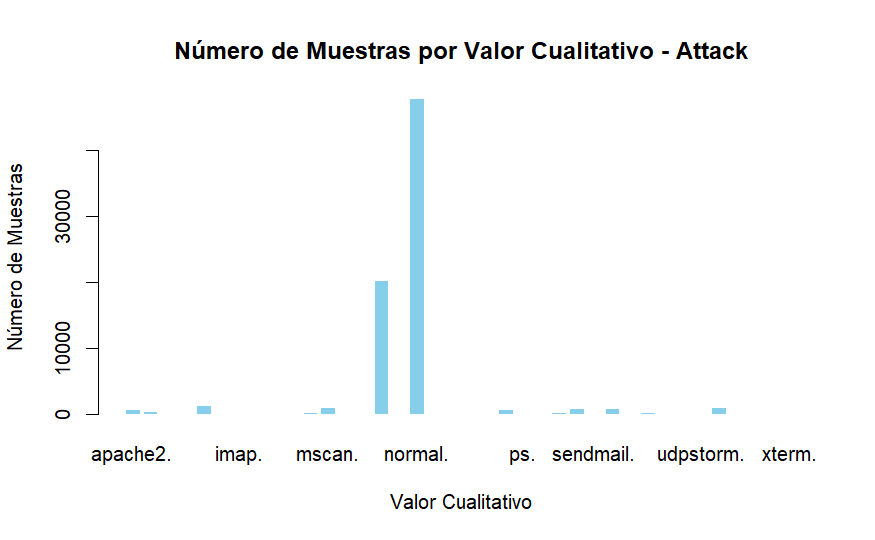

[output not shown]

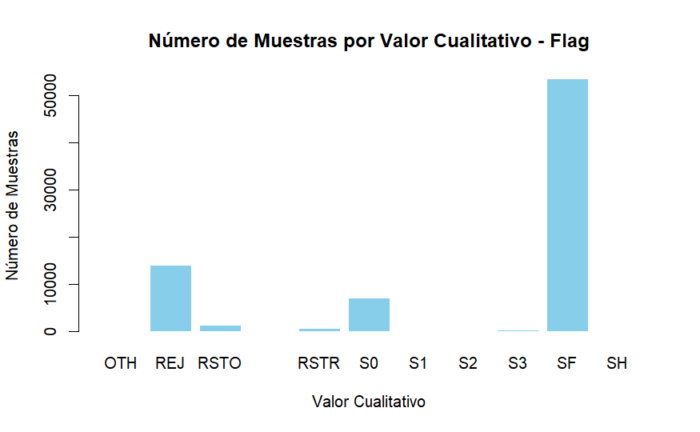

[output not shown]

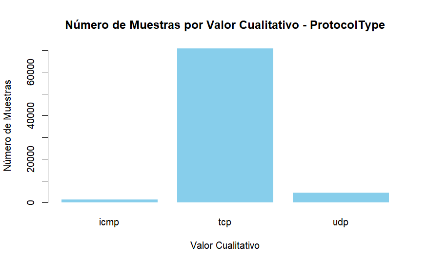

[output not shown]

[output cut: 51 more lines]

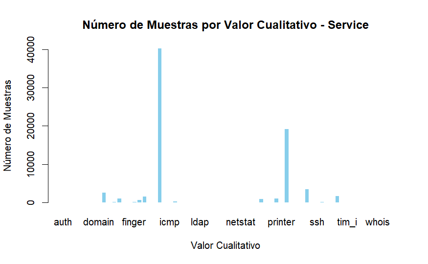

### 2.5.2 1.2. Validación de duplicados en el conjunto de datos de muestra

Vamos a validar si el conjunto de datos de muestra contiene filas duplicadas y, en caso afirmativo, eliminaremos las duplicadas.

| Duration | ProtocolType | Service | Flag | SrcBytes | DstBytes | Land | WrongFragment | Urgent | Hot | NumFailedLogin | LoggedIn | NumCompromised | RootShell | SuAttempted | NumRoot | NumFile | NumShells | NumAccessFiles | NumOutboundCmds | IsHostLogin | IsGuestLogin | Count | SrvCount | SerrorRate | SrvSerrorRate | RerrorRate | SrvRerrorRate | SameSrvRate | DiffSrvRate | … |
| --- | --- | --- | --- | --- | --- | --- | --- | --- | --- | --- | --- | --- | --- | --- | --- | --- | --- | --- | --- | --- | --- | --- | --- | --- | --- | --- | --- | --- | --- | --- |

```
Número de muestras duplicadas eliminadas: 0
```

## 2.6 Con el siguiente estudio se analiza el Dataset Muestra y el Dataset Global

```
Número de muestras duplicadas eliminadas: 221058
```

|  | Attack | n_Full | Percentage_Full | n_Ini | Percentage | Diferencia | Disponibles |
| --- | --- | --- | --- | --- | --- | --- | --- |
| 15 | neptune. | 20332 | 69.21 | 20332 | 69.21 | 0 | 0 |
| 5 | guess_passwd. | 1302 | 4.43 | 1302 | 4.43 | 0 | 0 |
| 12 | mscan. | 1049 | 3.57 | 1049 | 3.57 | 0 | 0 |
| 33 | warezmaster. | 1002 | 3.41 | 1002 | 3.41 | 0 | 0 |
| 27 | smurf. | 936 | 3.19 | 936 | 3.19 | 0 | 0 |
| 25 | satan. | 860 | 2.93 | 860 | 2.93 | 0 | 0 |
| 1 | apache2. | 794 | 2.70 | 794 | 2.70 | 0 | 0 |
| 21 | processtable. | 744 | 2.53 | 744 | 2.53 | 0 | 0 |
| 2 | back. | 386 | 1.31 | 386 | 1.31 | 0 | 0 |
| 24 | saint. | 364 | 1.24 | 364 | 1.24 | 0 | 0 |

[output cut: 27 more lines]

| Attack | n_Full | Percentage_Full | n_Ini | Percentage | Diferencia | Disponibles |
| --- | --- | --- | --- | --- | --- | --- |

|  | Attack | n_Full | Percentage_Full | n_Ini | Percentage | Diferencia | Disponibles |
| --- | --- | --- | --- | --- | --- | --- | --- |
| 27 | smurf. | 936 | 3.19 | 936 | 3.19 | 0 | 0 |
| 25 | satan. | 860 | 2.93 | 860 | 2.93 | 0 | 0 |
| 1 | apache2. | 794 | 2.70 | 794 | 2.70 | 0 | 0 |
| 21 | processtable. | 744 | 2.53 | 744 | 2.53 | 0 | 0 |
| 2 | back. | 386 | 1.31 | 386 | 1.31 | 0 | 0 |
| 24 | saint. | 364 | 1.24 | 364 | 1.24 | 0 | 0 |
| 29 | snmpguess. | 359 | 1.22 | 359 | 1.22 | 0 | 0 |
| 11 | mailbomb. | 308 | 1.05 | 308 | 1.05 | 0 | 0 |
| 28 | snmpgetattack. | 179 | 0.61 | 179 | 0.61 | 0 | 0 |
| 20 | portsweep. | 174 | 0.59 | 174 | 0.59 | 0 | 0 |

[output cut: 23 more lines]

## 2.7 Con el siguiente estudio se concluye que el Dataset Muestra es ya el Dataset Global filtrado y no es posible poblar el Dataset de trabajo

[figure not shown]

## 2.8 Tratamiento de las muestras residuales

|  | Attack | Total | Porcentaje |
| --- | --- | --- | --- |
| 1 | neptune. | 20332 | 69.21 |
| 2 | guess_passwd. | 1302 | 4.43 |
| 3 | mscan. | 1049 | 3.57 |
| 4 | warezmaster. | 1002 | 3.41 |
| 5 | smurf. | 936 | 3.19 |
| 6 | satan. | 860 | 2.93 |
| 7 | apache2. | 794 | 2.70 |
| 8 | processtable. | 744 | 2.53 |
| 9 | back. | 386 | 1.31 |
| 10 | saint. | 364 | 1.24 |

[output cut: 27 more lines]

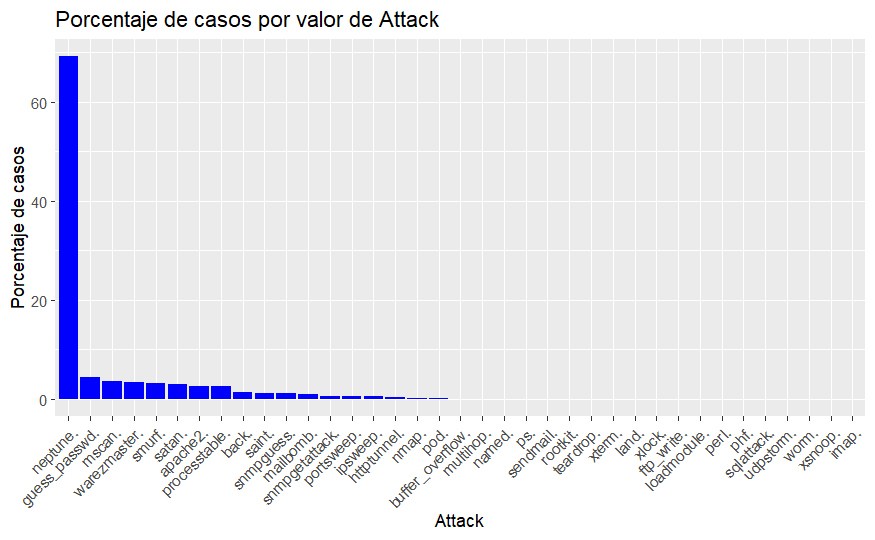

|  | Attack | Total | Porcentaje |
| --- | --- | --- | --- |
| 1 | neptune. | 20332 | 69.21 |
| 2 | guess_passwd. | 1302 | 4.43 |
| 3 | mscan. | 1049 | 3.57 |
| 4 | warezmaster. | 1002 | 3.41 |
| 5 | smurf. | 936 | 3.19 |
| 6 | satan. | 860 | 2.93 |
| 7 | apache2. | 794 | 2.70 |
| 8 | processtable. | 744 | 2.53 |
| 9 | back. | 386 | 1.31 |
| 10 | saint. | 364 | 1.24 |

[output cut: 8 more lines]

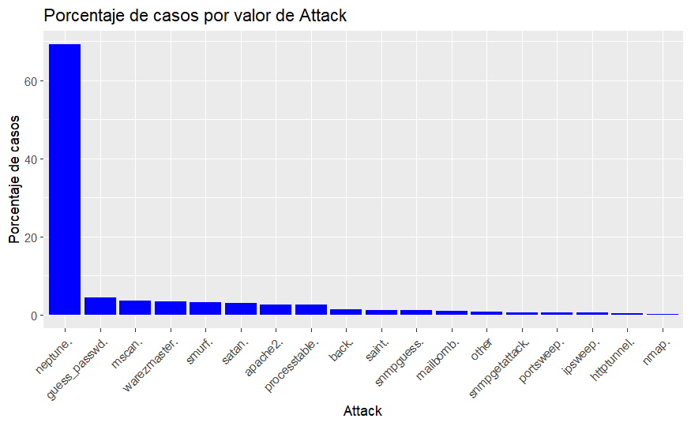

Aunque la creación de un buen modelo debe entenderse como un proceso iterativo, en el que se van ajustando y probando distintos modelos, existen ciertas pistas que pueden ayudar a realizar una selección inicial adecuada.

Si dos variables numéricas están muy correlacionadas, añaden información redundante al modelo, por lo tanto, no conviene incorporar ambas. Si esto ocurre, se puede: excluir aquella que, acorde al criterio del analista, no está realmente asociada con la variable respuesta; o combinarlas para recoger toda su información en una única nueva variable, por ejemplo, con un PCA.

Si una variable tiene varianza igual o próxima a cero (su valor es el mismo o casi el mismo para todas las observaciones) añade al modelo más ruido que información, por lo que suele ser conveniente excluirla.

Si alguno de los niveles de una variable cualitativa tiene muy pocas observaciones en comparación a los otros niveles, puede ocurrir que, durante la validación cruzada o bootstrapping, algunas particiones no contengan ninguna observación de dicha clase (varianza cero), lo que puede dar lugar a errores. En estos casos, suele ser conveniente eliminar las observaciones del grupo minoritario (si es una variable multiclase), eliminar la variable (si solo tiene dos niveles) o asegurar que, en la creación de las particiones, se garantice que todos los grupos estén representados en cada una de ellas.

## 2.9 Selección de Predictores

Sección de carga de los diferentes modelos de subset por variables

# 3 modulo de selección de las variables finales por criterios puramente estadísticos

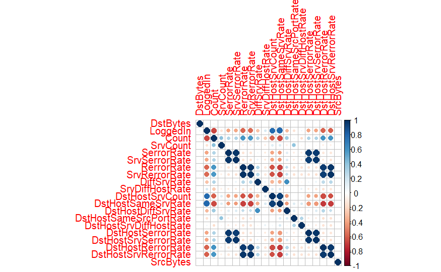

```
[1] 7737   14
[1] 7737   11
[1] 7737    6
[1] 7737    8
```

| Variable | Valor |
| --- | --- |
| Propuesto | 98.65 |
| Enunciado | 97.35 |
| Ejemplo_PDF | 98.41 |
| Teórico | 89.99 |

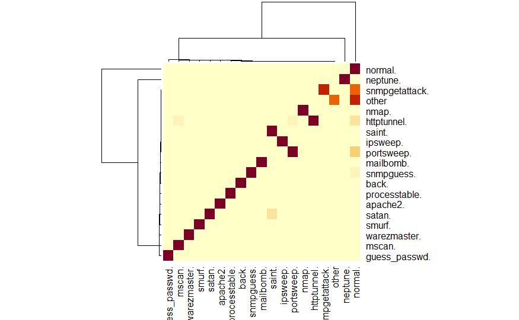

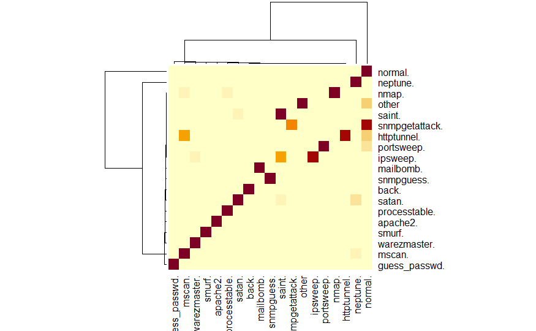

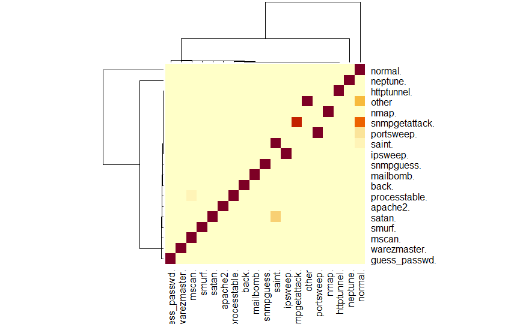

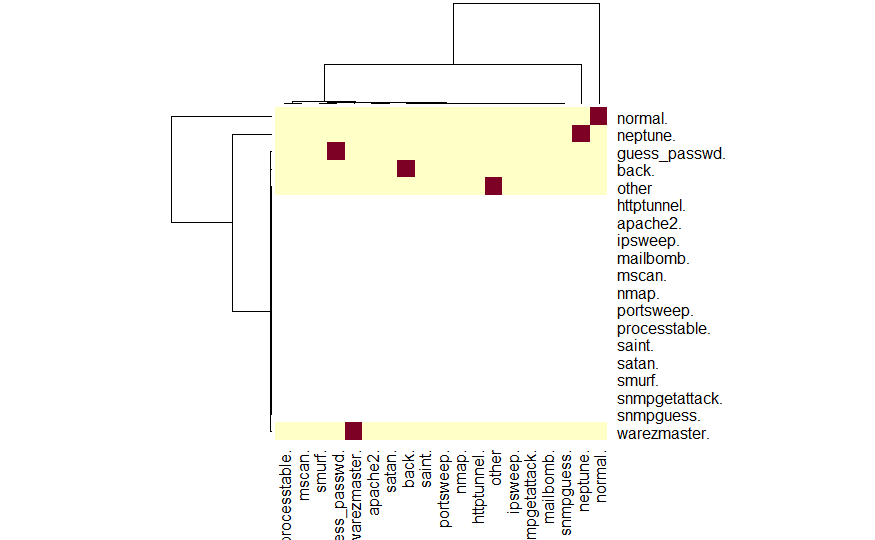

## 3.1 conclusión: nos quedamos con la propuesta púramente estadística

| Modelo | Precisión | Tiempo |
| --- | --- | --- |
| Random Forest | 98.63 | 1.8012490 secs |
| Support Vector Machine | 94.39 | 4.6432221 secs |
| Red Neuronal | 89.96 | 7.5464551 secs |
| CART | 88.88 | 1.6148641 secs |
| KNN | 97.03 | 9.9558828 secs |
| Naive | 57.57 | 0.1169429 secs |

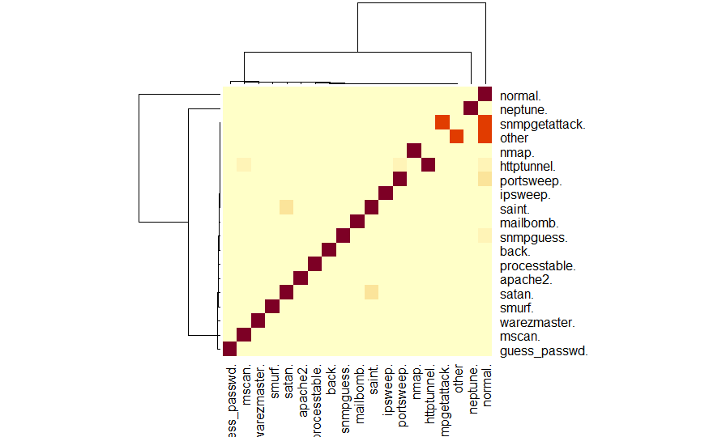

## 3.2 Entrenamiento con Random Forest Final

```
      apache2.          back.  guess_passwd.    httptunnel.       ipsweep.      mailbomb.
   0.010271935    0.004993661    0.016843903    0.001888794    0.002018163    0.003984579
        mscan.       neptune.          nmap.        normal.          other     portsweep.
   0.013583793    0.263033972    0.001034956    0.619860798    0.002716759    0.002251028
 processtable.         saint.         satan.         smurf. snmpgetattack.     snmpguess.
   0.009625087    0.004709048    0.011125773    0.012108981    0.002328650    0.004657300
  warezmaster.
   0.012962819

      apache2.          back.  guess_passwd.    httptunnel.       ipsweep.      mailbomb.
   0.010273795    0.004994565    0.016846954    0.001863258    0.001992650    0.003985301
        mscan.       neptune.          nmap.        normal.          other     portsweep.
   0.013560375    0.263081621    0.001035143    0.619947208    0.002691372    0.002251436
 processtable.         saint.         satan.         smurf. snmpgetattack.     snmpguess.
   0.009626831    0.004709901    0.011127788    0.012111174    0.002303193    0.004632265
  warezmaster.
   0.012965167
```

[output not shown]

# 4 EDA: Esta sección es para completar el estudio de los datos y sus relaciones

Categorias principales de intrusiones:

DOS: denial-of-service, e.g. syn flood; R2L: unauthorized access from a remote machine, e.g. guessing password; U2R: unauthorized access to local superuser (root) privileges, e.g., various ``buffer overflow’’ attacks; probing: surveillance and other probing, e.g., port scanning.